# Lec-26: Sentiment Analysis (part 1)

Published

October 28, 2024

```r
# packages
library(tidyverse)    # base tidy data tools
library(tidytext)     # text mining; gets along with tidyverse
library(janeaustenr)  # Jane Austen's novels
```

## Sentiment Analysis

We continue to use the text of the novel *Pride and Prejudice* by Jane Austen.

```r
# 1) data in a table
pride = tibble(
  "text" = prideprejudice
)

# 2) tokenize and remove stop_words
pride_tokens = pride |>
  unnest_tokens(input = text, output = word) |>
  anti_join(stop_words, by = "word") |>
  count(word, sort = TRUE, name = "count")

pride_tokens |> slice_head(n = 15)
```

```
# A tibble: 15 × 2
   word      count
   <chr>     <int>
 1 elizabeth   597
 2 darcy       373
 3 bennet      294
 4 miss        283
 5 jane        264
 6 bingley     257
 7 time        203
 8 lady        183
 9 sister      180
10 wickham     162
11 dear        158
12 collins     156
13 family      151
14 day         140
15 lydia       133
```

## Sentiment Lexicons

We can use the tools of text mining to approach the emotional content of text. One way to analyze the sentiment of a text is to consider the text as a combination of its individual words, and the sentiment of the whole text as the sum of the sentiment content of the individual words.

This isn’t the only way to approach sentiment analysis, but it is the most common one.

The `"tidytext"` package comes with the `sentiments` dataset that contains a dictionary or **lexicon** (curated by Bing Liu) of words and their associated sentiment.

```r
rbind(head(sentiments, 5), tail(sentiments, 5))
```

```
# A tibble: 10 × 2
   word       sentiment
   <chr>      <chr>
 1 2-faces    negative
 2 abnormal   negative
 3 abolish    negative
 4 abominable negative
 5 abominably negative
 6 zealously  negative
 7 zenith     positive
 8 zest       positive
 9 zippy      positive
10 zombie     negative
```

### Sentiment Lexicons in Tidytext

Bing Liu’s sentiment lexicon is based on unigrams (i.s. single words). It contains many English words and the words are assigned a sentiment label `positive` or `negative`.

In addition to the `sentiments` dataset, `"tidytext"` also has the `get_sentiments()` function that allows us to obtain more sentiment lexicons:

- `"bing"`: from Bing Liu; this lexicon categorizes words in a binary fashion into positive and negative categories.
- `"afinn"`: from Finn Arup Nielsen; this lexicon assigns words with a score that runs between -5 and 5, with negative scores indicating negative sentiment and positive scores indicating positive sentiment.
- `"nrc"`: from Saif Mohammad and Peter Turney; this lexicon categorizes words in a binary fashion (`"yes"` / `"no"`) into categories of positive, negative, anger, anticipation, disgust, fear, joy, sadness, surprise, and trust.
- `"loughran"`: another lexicon somewhat similar to `"afinn"`.

You can use `get_sentiments()`

```r
# AFINN
afinn = get_sentiments(lexicon = "afinn")
afinn |> slice_head(n = 10)
```

```
# A tibble: 10 × 2
   word       value
   <chr>      <dbl>
 1 abandon       -2
 2 abandoned     -2
 3 abandons      -2
 4 abducted      -2
 5 abduction     -2
 6 abductions    -2
 7 abhor         -3
 8 abhorred      -3
 9 abhorrent     -3
10 abhors        -3
```

```r
nrc = get_sentiments("nrc")
nrc |> slice_head(n = 10)
```

```
# A tibble: 10 × 2
   word        sentiment
   <chr>       <chr>
 1 abacus      trust
 2 abandon     fear
 3 abandon     negative
 4 abandon     sadness
 5 abandoned   anger
 6 abandoned   fear
 7 abandoned   negative
 8 abandoned   sadness
 9 abandonment anger
10 abandonment fear
```

### Sentiment Analysis with Inner Join

With data in a tidy format, the sentiments of words can be added to our data table with an inner join via `inner_join()`.

```r
pride_sentim = inner_join(pride_tokens, sentiments, by = "word")
```

Notice that the word `"miss"` is being handled by the sentiment lexicons as related to the verb *to miss*, instead of a title prefixed to the name of a woman as in *miss Emma*. Because of this, we are going to exclude the token `"miss"` from our analysis:

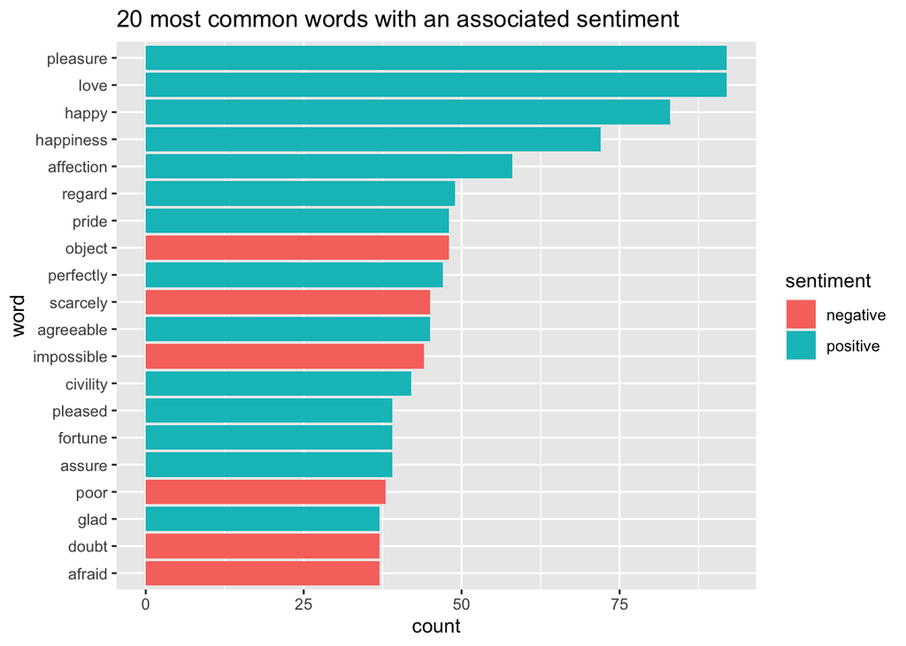

```r
pride_sentim |>
  filter(word != "miss") |>
  slice_head(n = 20) |>
  ggplot(aes(x = count, y = reorder(word, count), fill = sentiment)) +
  geom_col() +
  labs(title = "20 most common words with an associated sentiment",
       y = "word")
```

## Sentiment Score by Chapter

Another type of sentiment analysis that can be performed on the `prideprejudice` text is to compute a sentiment score for each chapter in the book.

Notice that `prideprejudice` contains elements indicating where a chapter begins, like element 7 in the following output (`"Chapter 1"`)

```r
head(prideprejudice, n = 20)
```

```
 [1] "PRIDE AND PREJUDICE"
 [2] ""
 [3] "By Jane Austen"
 [4] ""
 [5] ""
 [6] ""
 [7] "Chapter 1"
 [8] ""
 [9] ""
[10] "It is a truth universally acknowledged, that a single man in possession"
[11] "of a good fortune, must be in want of a wife."
[12] ""
[13] "However little known the feelings or views of such a man may be on his"
[14] "first entering a neighbourhood, this truth is so well fixed in the minds"
[15] "of the surrounding families, that he is considered the rightful property"
[16] "of some one or other of their daughters."
[17] ""
[18] "\"My dear Mr. Bennet,\" said his lady to him one day, \"have you heard that"
[19] "Netherfield Park is let at last?\""
[20] ""
```

We need to do a bit of text processing in order to split the text into chapters. Here are the proposed steps:

1. collapse `prideprejudice` into a single element vector
2. split text into chapters using a regex pattern `"Chapter \\d+"`
3. assemble table with columns `"chapter"` and “text”`

```r
# 1) collapse text into one-element vector
pride_collapsed = paste(prideprejudice, collapse = " ")

# 2) split text into chapters
pride_split = str_split(pride_collapsed, pattern = "Chapter \\d+")

class(pride_split)
```

```
[1] "list"
```

```r
pride_chapters = pride_split[[1]][-1]
```

```r
# 3) table of chapters, and their text content
pride_dat = tibble(
  "chapter" = 1:length(pride_chapters),
  "text" = pride_chapters
)
```

The we proceed as usual: tokenizing the text, removing stopwords, and getting word counts:

```r
# tokenize, remove stop-words, and get frequencies
pride_tokens = pride_dat |>
  unnest_tokens(input = text, output = word) |>
  anti_join(stop_words, by = "word") |>
  count(chapter, word, sort = TRUE, name = "count")

slice_head(pride_tokens, n = 10)
```

```
# A tibble: 10 × 3
   chapter word      count
     <int> <chr>     <int>
 1      43 elizabeth    36
 2      18 darcy        33
 3      18 elizabeth    25
 4      45 miss         22
 5      16 darcy        21
 6      29 lady         21
 7       8 bingley      20
 8      10 darcy        20
 9      18 bingley      19
10      29 catherine    19
```

Then we attach sentiments to those words that appear in Bing’s lexicon:

```r
# remove "miss"
pride_sentims = inner_join(pride_tokens, sentiments, by = "word") |>
  filter(word != "miss")

slice_head(pride_sentims, n = 10)
```

```
# A tibble: 10 × 4
   chapter word         count sentiment
     <int> <chr>        <int> <chr>
 1      43 master          13 positive
 2      16 pride           11 positive
 3      55 happy           10 positive
 4       8 accomplished     8 positive
 5      25 love             8 positive
 6      43 handsome         8 positive
 7       5 pride            7 positive
 8      18 pleasure         7 positive
 9      59 happy            7 positive
10      59 love             7 positive
```

Having identified the type of `sentiment` for each word, we then use `pivot_wider()` to “unfold” this column into 2 new columns: `positive` and `negative`. After that, we summarise a `score` column, grouping by `chapter`, based on the number of positive words minus number of negative words.

```r
pride_scores_by_chapter = pride_sentims |>
  pivot_wider(names_from = sentiment, values_from = count, values_fill = 0) |>
  group_by(chapter) |>
  summarise(score = sum(positive) - sum(negative))

slice_head(pride_scores_by_chapter, n = 10)
```

```
# A tibble: 10 × 2
   chapter score
     <int> <int>
 1       1     1
 2       2    -4
 3       3    30
 4       4    28
 5       5    17
 6       6    42
 7       7    -8
 8       8    10
 9       9    36
10      10    20
```

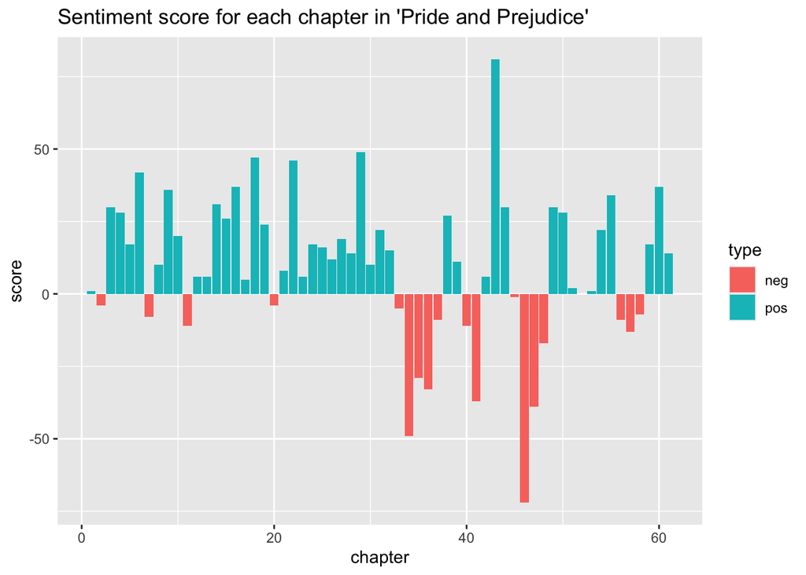

```r
pride_scores_by_chapter |>
  mutate(type = case_when(
    score >= 0 ~ "pos",
    score < 0 ~ "neg"
  )) |>
  ggplot(aes(x = chapter, y = score, fill = type)) +
  geom_col() +
  labs(title = "Sentiment score for each chapter in 'Pride and Prejudice'")
```